# nth introduction to Jupyter... but this time with Docker :)

This jupyter notebook is in response to the assignment of the Programming subject of the MSc in Particle Physics and Cosmology at the UC that I (Joan Ribot Oliver, from Manacor, Mallorca) am currently studying.

The assignment asks to follow and reproduce the Jupyter Notebooks for Beginners tutorial, so this is what will be done. The document must also be rendered as a .html, so that by the end of the notebook it will be done as well.

I will skip the first steps of the tutorial because in the Docker lesson we learned how to run a container with jupyter notebooks, so I will ignore the installation process. The first basic steps are really easy:

```python
print("Hola món!")
```

```
Hola món!
```

```python
import time
time.sleep(1)
```

```python
def say_hello(recipient):
    return 'Hola {}, com va això?'.format(recipient)
say_hello('Jordi')
```

```
'Hola Jordi, com va això?'
```

# This is a level 1 heading

## This is a level 2 heading

This is some plain text that forms a paragraph. Add emphasis via **bold** or **bold**, and *italic* or *italic*.

Paragraphs must be separated by an empty line.

- Sometimes we want to include lists.
- Which can be bulleted using asterisks.
1. Lists can also be numbered.
2. If we want an ordered list.

[It is possible to include hyperlinks](https://www.dataquest.io)

Inline code uses single backticks: `foo()`, and code blocks use triple backticks:

```
bar()
```

Or can be indented by 4 spaces:

```
    foo()
```

The content of the previous cell is presented in the next code cell.

To add images is easy if the image is uploaded to the web. An easier way for me is to upload the image to the working directory and call it with the next code cell

[figure not shown]

```python
from IPython.display import Image
Image("Markdowns.png")
```

```python
import numpy as np
def square(x):
    return x * x
```

```python
x = np.random.randint(1, 10)
y = square(x)
print('%d squared is %d' % (x, y))
```

```
2 squared is 4
```

```python
y = 10
print('%d squared is %d' % (x, y))
```

```
2 squared is 10
```

y is redefined and its value is not x$*$x anymore. However, the x value is still the same because x = np.random.randint(1, 10) isn't executed again, so x value hasn't changed.

```python
%matplotlib inline

import pandas as pd
import matplotlib.pyplot as plt
import seaborn as sns

sns.set(style="darkgrid")
```

Many python libraries can be imported and redefined.\

## Data set up

As an example of data set up and to do some plots, the fortune500.csv file will be used.\

First of all the file must be read.

```python
df = pd.read_csv('fortune500.csv')
```

Then check the initial and final data, to find out it's format, content, structure and size.

```python
df.head()
```

|  | Year | Rank | Company | Revenue (in millions) | Profit (in millions) |
| --- | --- | --- | --- | --- | --- |
| 0 | 1955 | 1 | General Motors | 9823.5 | 806 |
| 1 | 1955 | 2 | Exxon Mobil | 5661.4 | 584.8 |
| 2 | 1955 | 3 | U.S. Steel | 3250.4 | 195.4 |
| 3 | 1955 | 4 | General Electric | 2959.1 | 212.6 |
| 4 | 1955 | 5 | Esmark | 2510.8 | 19.1 |

```python
df.tail()
```

|  | Year | Rank | Company | Revenue (in millions) | Profit (in millions) |
| --- | --- | --- | --- | --- | --- |
| 25495 | 2005 | 496 | Wm. Wrigley Jr. | 3648.6 | 493 |
| 25496 | 2005 | 497 | Peabody Energy | 3631.6 | 175.4 |
| 25497 | 2005 | 498 | Wendy's International | 3630.4 | 57.8 |
| 25498 | 2005 | 499 | Kindred Healthcare | 3616.6 | 70.6 |
| 25499 | 2005 | 500 | Cincinnati Financial | 3614.0 | 584 |

One can redefine the columns for an easier treatment of them in the future.

```python
df.columns = ['year', 'rank', 'company', 'revenue', 'profit']
```

To figure out its extension the len() command can be used.

```python
len(df)
```

```
25500
```

To figure out the data type the command to use is the next one

```python
df.dtypes
```

```
year         int64
rank         int64
company     object
revenue    float64
profit      object
dtype: object
```

Profit is expected to be a float64, that is to say just numbers. To find the data that is different from the expected (numeric):

```python
non_numberic_profits = df.profit.str.contains('[^0-9.-]')
df.loc[non_numberic_profits].head()
```

|  | year | rank | company | revenue | profit |
| --- | --- | --- | --- | --- | --- |
| 228 | 1955 | 229 | Norton | 135.0 | N.A. |
| 290 | 1955 | 291 | Schlitz Brewing | 100.0 | N.A. |
| 294 | 1955 | 295 | Pacific Vegetable Oil | 97.9 | N.A. |
| 296 | 1955 | 297 | Liebmann Breweries | 96.0 | N.A. |
| 352 | 1955 | 353 | Minneapolis-Moline | 77.4 | N.A. |

```python
set(df.profit[non_numberic_profits])
```

```
{'N.A.'}
```

```python
len(df.profit[non_numberic_profits])
```

```
369
```

Now the length of the unknown data (N.A.) is known. Then a histogram plot of the missing data per each year can be done

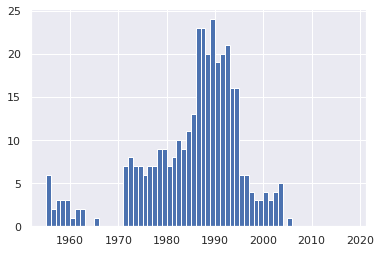

```python
bin_sizes, _, _ = plt.hist(df.year[non_numberic_profits], bins=range(1955, 2019))
```

Not so many data is lost even in the worst cases, 24 out of 500. For this case, it's an acceptable data set and the unknown values' rows are removed.

```python
df = df.loc[~non_numberic_profits]
df.profit = df.profit.apply(pd.to_numeric)
```

```python
len(df)
```

```
25131
```

```python
df.dtypes
```

```
year         int64
rank         int64
company     object
revenue    float64
profit     float64
dtype: object
```

Now the length of the whole data is a bit smaller and the profit data is of the expected type.

## Plotting

```python
group_by_year = df.loc[:, ['year', 'revenue', 'profit']].groupby('year')
avgs = group_by_year.mean()
x = avgs.index
y1 = avgs.profit
def plot(x, y, ax, title, x_label, y_label):
    ax.set_title(title)
    ax.set_xlabel(x_label)
    ax.set_ylabel(y_label)
    ax.plot(x, y)
    ax.margins(x=0, y=0)
```

A plot function is defined and all its variables. Then the function is called and the plot is done according to the variables defined.

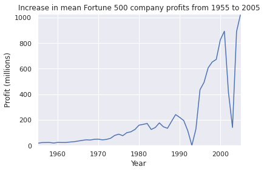

```python
fig, ax = plt.subplots()
plot(x, y1, ax, 'Increase in mean Fortune 500 company profits from 1955 to 2005', 'Year', 'Profit (millions)')
```

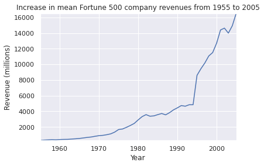

```python
y2 = avgs.revenue
fig, ax = plt.subplots()
plot(x, y2, ax, 'Increase in mean Fortune 500 company revenues from 1955 to 2005', 'Year', 'Revenue (millions)')
```

The same can be done with the standard deviation.

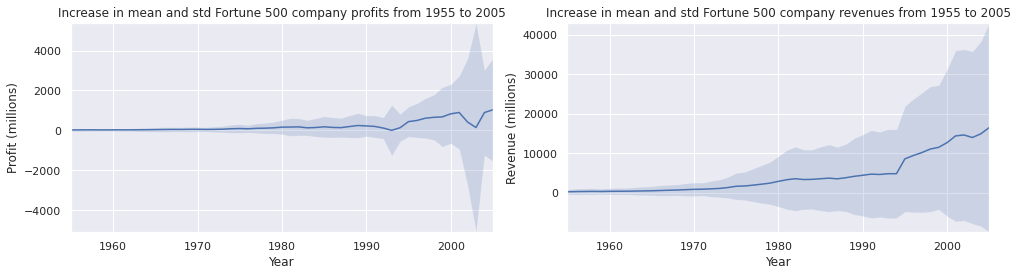

```python
def plot_with_std(x, y, stds, ax, title, x_label, y_label):
    ax.fill_between(x, y - stds, y + stds, alpha=0.2)
    plot(x, y, ax, title, x_label, y_label)
fig, (ax1, ax2) = plt.subplots(ncols=2)
title = 'Increase in mean and std Fortune 500 company %s from 1955 to 2005'
stds1 = group_by_year.std().profit.values
stds2 = group_by_year.std().revenue.values
plot_with_std(x, y1.values, stds1, ax1, title % 'profits', 'Year', 'Profit (millions)')
plot_with_std(x, y2.values, stds2, ax2, title % 'revenues', 'Year', 'Revenue (millions)')
fig.set_size_inches(14, 4)
fig.tight_layout()
```

The comand "pip3 install ipywidgets" must be executed in the terminal to install the package. Then, interactive plots can be done.

```python
import ipywidgets as widgets
from IPython.display import display

def update_plot(year_range):
    start_year, end_year = year_range
    mask = (x >= start_year) & (x <= end_year)

    fig, ax = plt.subplots(figsize=(10, 6))
    plot(x[mask], y1[mask], ax, f'Increase in mean Fortune 500 company profits from {start_year} to {end_year}', 'Year', 'Profit (millions)')
    plt.show()

year_range_slider = widgets.IntRangeSlider(
    value=[1955, 2005],
    min=1955,
    max=2005,
    step=1,
    description='Year range:',
    continuous_update=False
)

widgets.interact(update_plot, year_range=year_range_slider)
```

```
interactive(children=(IntRangeSlider(value=(1955, 2005), continuous_update=False, description='Year range:', m…
```

```
<function __main__.update_plot(year_range)>
```

The command "pip install jupyterlab" must be executed in terminal to install jupyterlab, but that is for another tutorial.